# VAR Analysis (Detrended)

Muhammad Uzair Aslam (18097), Mustafa Qamar Shamim (17988) and Sahad Morani (18000)

17/05/2021

#VAR Analysis

In this file we plan to explore short run effects by detrended CPI,M2 and Industrial Production and try to replicate Mahmood(Volume 4, Number 1, November, 2008).

```r
library(urca)
library(vars)
library(mFilter)
library(tseries)
library(forecast)
library(tidyverse)
library(tsDyn)
library(zoo)
library(tsbox)
#below function reads the data from csv file
#Input : String of file
#Output: dataframe
read_data <- function(data){
  data <- read.csv(data)
  data$M2 <- as.numeric(data$M2)
  return(data)
}

df<-read_data("Data.csv")

#convert all columns to monthly time series
cpi <- ts(df$CPI,frequency=12, start=c(1991,1))
ipilsm <- ts(df$IPILSM,frequency=12, start=c(1991,1))
m2 <- ts(df$M2,frequency=12, start=c(1991,1))



# detrending Using HP-Filter
lcpi <- log(cpi)
lipi <- log(ipilsm)
lm2 <- log(m2)

lcpi.hp <- hpfilter(lcpi, freq=14400, drift=FALSE)
lipi.hp <- hpfilter(lipi, freq=14400, drift=FALSE)
lm2.hp <- hpfilter(lm2, freq=14400, drift=FALSE)

df$lcpi.cycle <- lcpi.hp$cycle
df$lipi.cycle <-lipi.hp$cycle
df$lm2.cycle <- lm2.hp$cycle

ndiffs(lcpi)
```

```
## [1] 1
```

```r
#difference of log(cpi),log(ipi) and log(m2)
dlcpi=c(NA, diff(lcpi, 1))
dlipi =c(NA, diff(lipi, 1))
dlm2=c(NA, diff(lm2, 1))

ndiffs(dlcpi)
```

```
## [1] 0
```

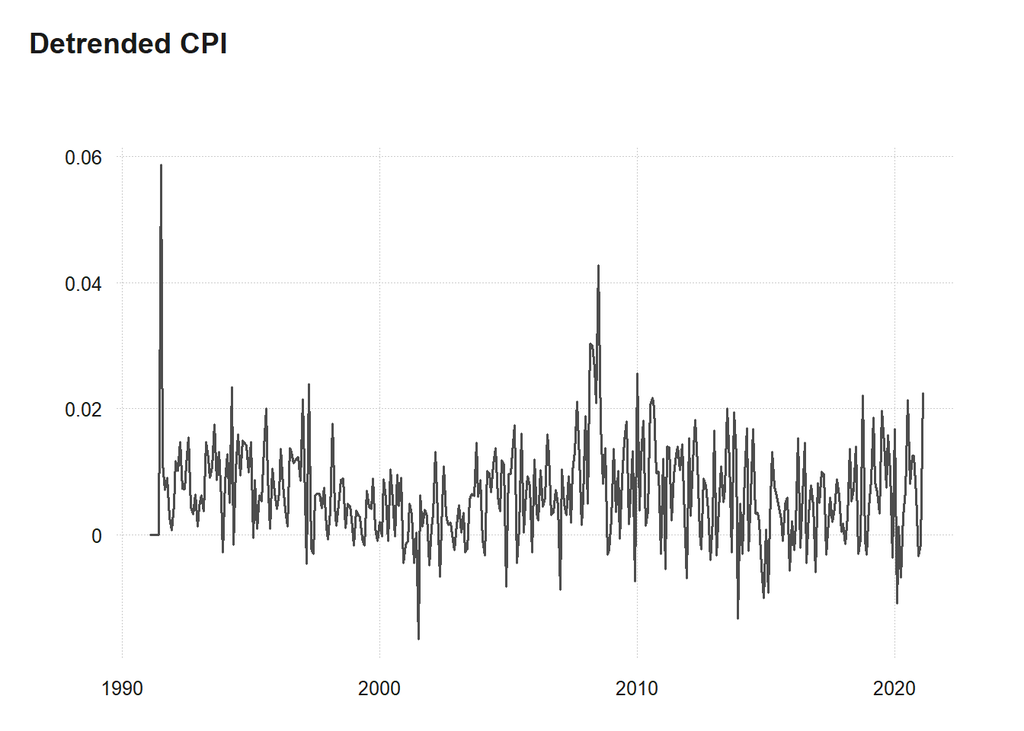

```r
#convert all columns to monthly time series
dlcpi <- ts(dlcpi,frequency=12, start=c(1991,1))
dlipi <- ts(dlipi,frequency=12, start=c(1991,1))
dlm2 <- ts(dlm2,frequency=12, start=c(1991,1))


#first remove NA's
cpi_up <- dlcpi[!is.na(dlcpi)]
m2_up<- dlm2[!is.na(dlm2)]
ipilsm_up<- dlipi[!is.na(dlipi)]


y1 <- data.frame(cpi_up, m2_up,ipilsm_up)
y1 <- y1[-1,]

#plot all series
ts_plot(dlcpi,title = "Detrended CPI")
```

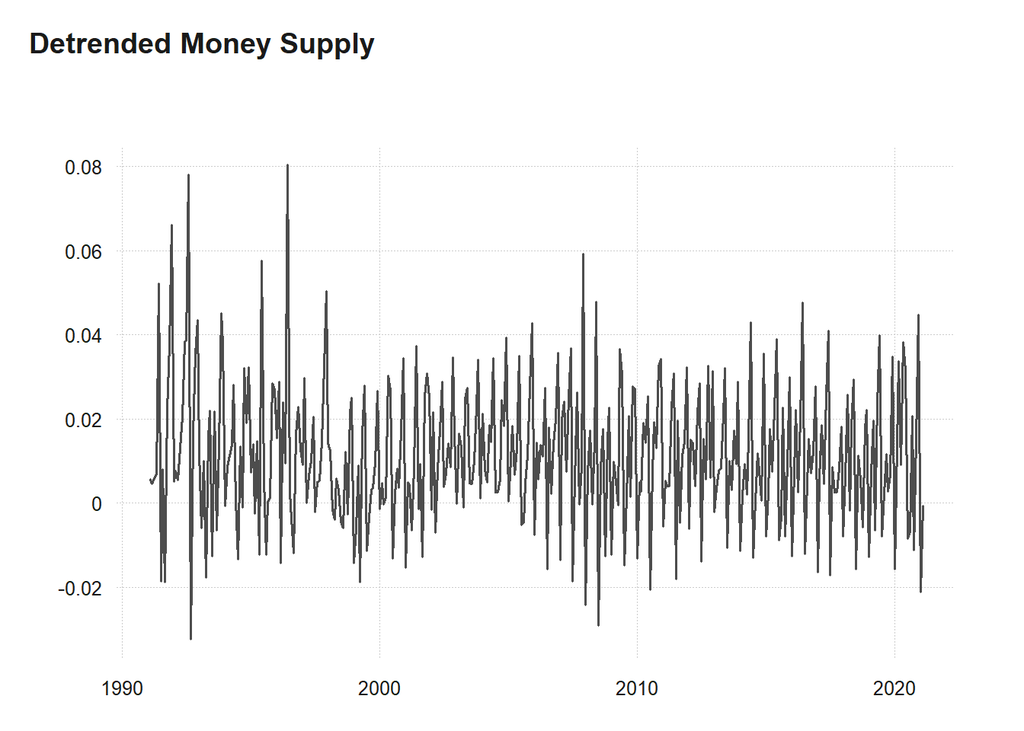

```r
ts_plot(dlm2,title ="Detrended Money Supply" )
```

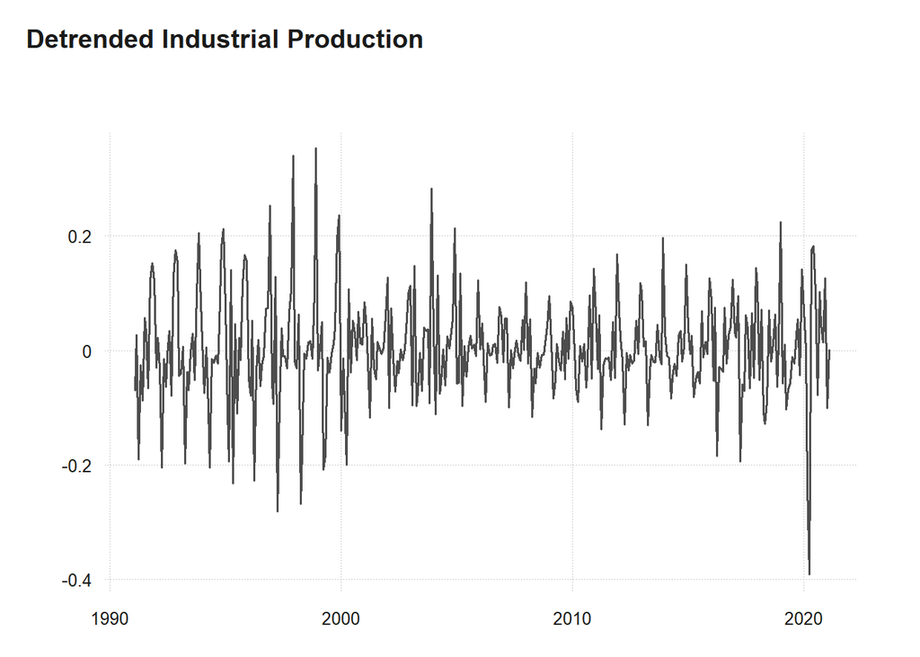

```r
ts_plot(dlipi,title = "Detrended Industrial Production")
```

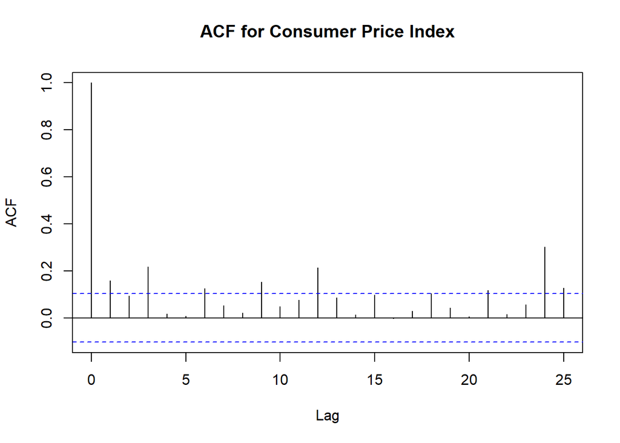

```r
#determine the persistence for CPI
#Moving Average Component
acf(cpi_up,main = "ACF for Consumer Price Index")
```

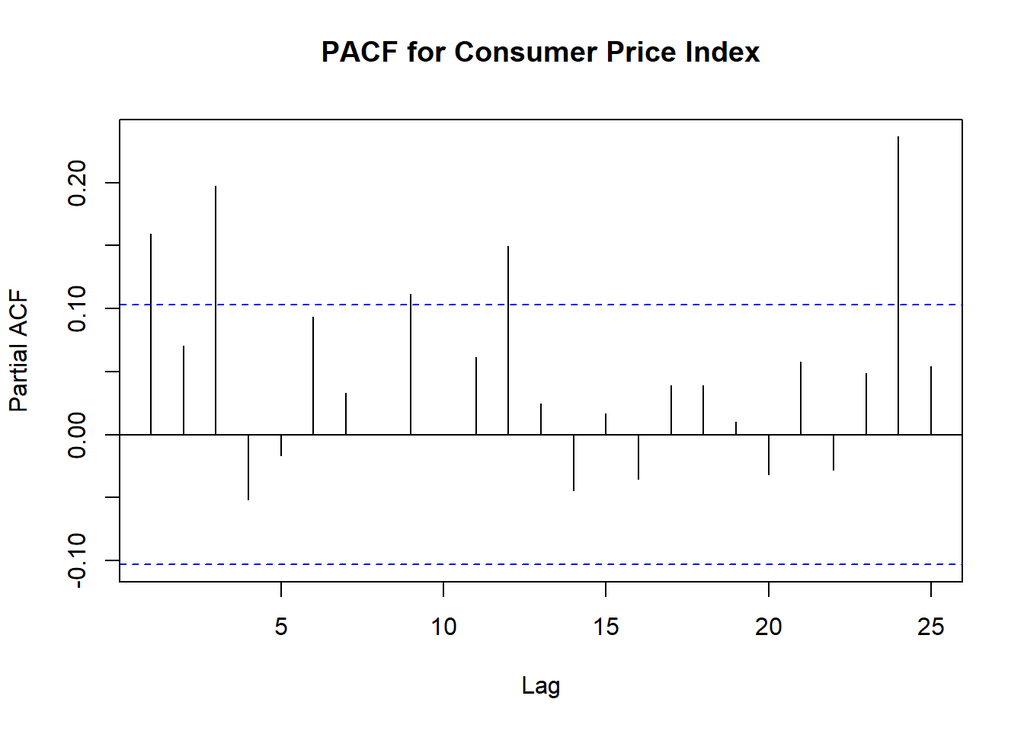

```r
#AR component
pacf(cpi_up,main = "PACF for Consumer Price Index")
```

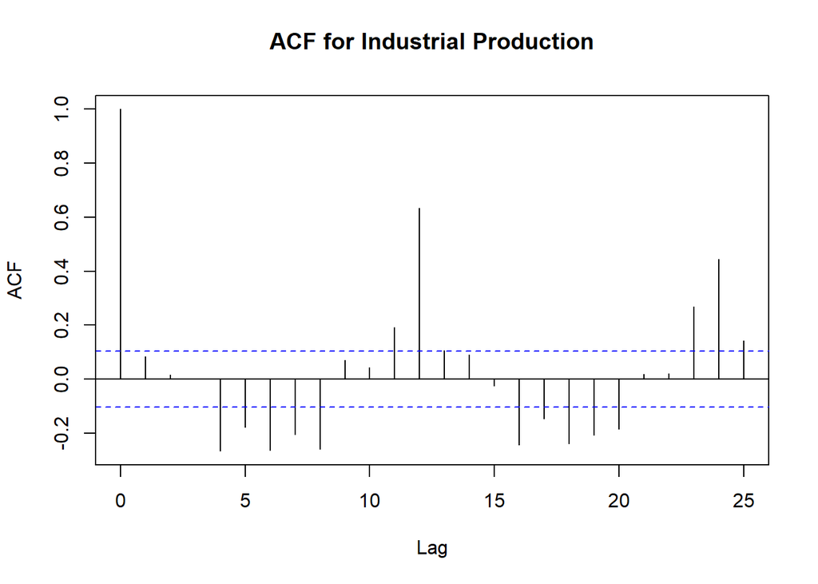

```r
#Shows that most of the lags are within the bound and insignificant

#determine the persistence for Industrial Production
#Moving Average Component
acf(ipilsm_up,main = "ACF for Industrial Production")
```

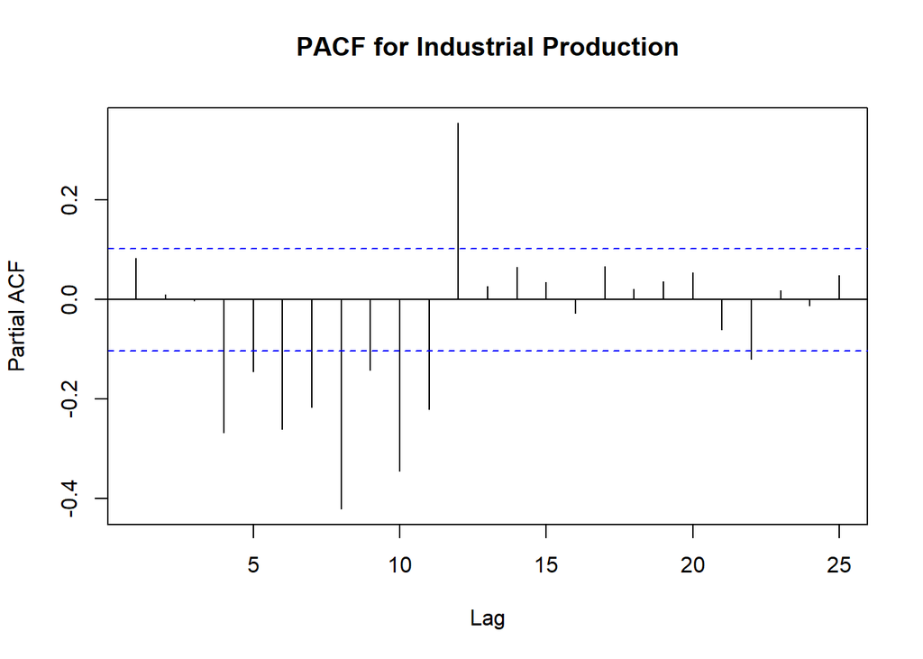

```r
#AR component
pacf(ipilsm_up,main = "PACF for Industrial Production")
```

```r
#Shows that most of the lags are within the bound and insignificant
```

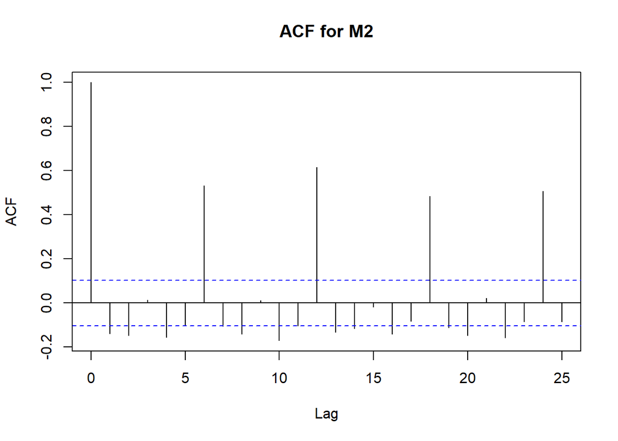

```r
#determine the persistence for Money Supply
#Moving Average Component
acf(m2_up,main = "ACF for M2")
```

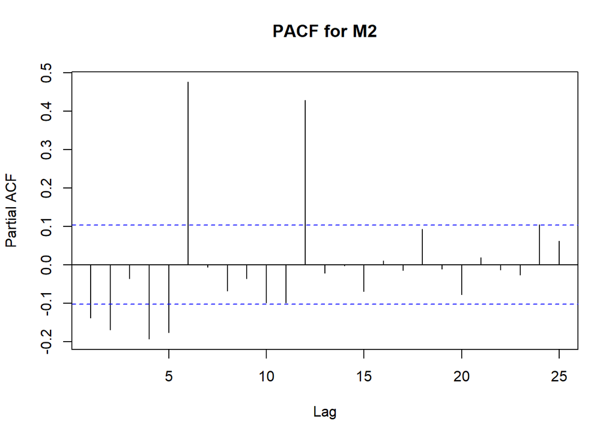

```r
pacf(m2_up,main = "PACF for M2")
```

```r
#Shows that most of the lags are within the bound and insignificant
```

```r
#bind the needed data.
spec_1_data <- cbind(cpi_up,m2_up,ipilsm_up)

#we find optimal lags using  VARselection
#Finding Optimal lags
lagselect<-VARselect(spec_1_data,lag.max = 12,type ="both") #we are using both trend and intercept
lagselect$selection
```

```
## AIC(n)  HQ(n)  SC(n) FPE(n)
##     12     12     12     12
```

```r
#We will use 12 as optimal lags so our model will be called as VAR(12)
```

Specification 1 : First, we estimate reduced form VAR models and does not impose structure and let the data speak itself! Based on difference stationary of IPI, CPI, and LM2.

```r
#Building VAR
Spec_1<- VAR(spec_1_data,p = 12,type = "const", season = 12)
#Show summary
summary(Spec_1)
```

```
##
## VAR Estimation Results:
## =========================
## Endogenous variables: cpi_up, m2_up, ipilsm_up
## Deterministic variables: const
## Sample size: 349
## Log Likelihood: 2930.887
## Roots of the characteristic polynomial:
## 0.9677 0.9677 0.9669 0.9669 0.9513 0.9513 0.9349 0.9349 0.9342 0.9342 0.9337 0.9028 0.9028 0.8819 0.8819 0.8783 0.8783 0.8703 0.8703 0.8603 0.8603 0.8485 0.8485 0.8468 0.8468 0.8406 0.8406 0.8366 0.8366 0.8291 0.8291 0.8246 0.8246 0.8043 0.8043 0.5704
## Call:
## VAR(y = spec_1_data, p = 12, type = "const", season = 12L)
##
##
## Estimation results for equation cpi_up:
## =======================================
## cpi_up = cpi_up.l1 + m2_up.l1 + ipilsm_up.l1 + cpi_up.l2 + m2_up.l2 + ipilsm_up.l2 + cpi_up.l3 + m2_up.l3 + ipilsm_up.l3 + cpi_up.l4 + m2_up.l4 + ipilsm_up.l4 + cpi_up.l5 + m2_up.l5 + ipilsm_up.l5 + cpi_up.l6 + m2_up.l6 + ipilsm_up.l6 + cpi_up.l7 + m2_up.l7 + ipilsm_up.l7 + cpi_up.l8 + m2_up.l8 +…
##
##                 Estimate Std. Error t value Pr(>|t|)
## cpi_up.l1      1.437e-01  5.847e-02   2.458  0.01454 *
## m2_up.l1       1.776e-02  3.217e-02   0.552  0.58128
## ipilsm_up.l1   2.781e-03  6.528e-03   0.426  0.67036
## cpi_up.l2      1.074e-01  5.889e-02   1.824  0.06910 .
## m2_up.l2       6.775e-03  3.112e-02   0.218  0.82780
## ipilsm_up.l2  -3.777e-03  6.914e-03  -0.546  0.58527
## cpi_up.l3      1.712e-01  5.852e-02   2.926  0.00370 **
## m2_up.l3       2.856e-02  3.103e-02   0.920  0.35812
## ipilsm_up.l3   2.037e-04  7.151e-03   0.028  0.97729
## cpi_up.l4      2.258e-02  5.921e-02   0.381  0.70321
## m2_up.l4       8.210e-03  3.135e-02   0.262  0.79359
## ipilsm_up.l4  -8.154e-03  7.445e-03  -1.095  0.27426
## cpi_up.l5      1.816e-02  5.904e-02   0.308  0.75862
## m2_up.l5       2.167e-02  3.147e-02   0.689  0.49161
## ipilsm_up.l5  -1.582e-02  7.628e-03  -2.074  0.03891 *
## cpi_up.l6     -1.733e-02  5.919e-02  -0.293  0.76986
## m2_up.l6      -1.326e-02  3.177e-02  -0.417  0.67681
## ipilsm_up.l6  -9.971e-03  7.416e-03  -1.345  0.17977
## cpi_up.l7      4.888e-02  5.506e-02   0.888  0.37532
## m2_up.l7       5.117e-02  3.192e-02   1.603  0.10994
## ipilsm_up.l7  -7.508e-03  7.477e-03  -1.004  0.31617
## cpi_up.l8      7.512e-03  5.483e-02   0.137  0.89111
```

[output cut: 156 more lines]

```
## F-statistic: 13.84 on 47 and 301 DF,  p-value: < 2.2e-16
##
##
##
## Covariance matrix of residuals:
##               cpi_up      m2_up ipilsm_up
## cpi_up     4.172e-05 -1.409e-06 3.790e-05
## m2_up     -1.409e-06  1.228e-04 5.910e-06
## ipilsm_up  3.790e-05  5.910e-06 3.138e-03
##
## Correlation matrix of residuals:
##             cpi_up     m2_up ipilsm_up
## cpi_up     1.00000 -0.019689  0.104748
## m2_up     -0.01969  1.000000  0.009522
## ipilsm_up  0.10475  0.009522  1.000000
```

```r
#Coefficient matrices of the lagged endogenous variables
Acoef(Spec_1)
```

```
## [[1]]
##             cpi_up.l1     m2_up.l1 ipilsm_up.l1
## cpi_up     0.14370821  0.017760886  0.002781405
## m2_up      0.01957729 -0.050072530 -0.002927293
## ipilsm_up -0.05080812  0.008520581 -0.371945544
##
## [[2]]
##             cpi_up.l2    m2_up.l2 ipilsm_up.l2
## cpi_up     0.10743439 0.006775194 -0.003776948
## m2_up     -0.05981554 0.005460754  0.008382132
## ipilsm_up -0.49736199 0.367838266 -0.381886658
##
## [[3]]
##             cpi_up.l3   m2_up.l3  ipilsm_up.l3
## cpi_up     0.17122420 0.02855582  0.0002037387
## m2_up      0.06982162 0.12947660 -0.0029146393
## ipilsm_up -0.23646688 0.24157658 -0.3399938680
##
## [[4]]
##             cpi_up.l4     m2_up.l4 ipilsm_up.l4
## cpi_up     0.02258181  0.008209612 -0.008154245
## m2_up     -0.03743923 -0.010400370 -0.024975412
## ipilsm_up  0.13712015  0.653089110 -0.357238367
##
## [[5]]
##             cpi_up.l5    m2_up.l5  ipilsm_up.l5
## cpi_up     0.01815931  0.02167267 -0.0158226680
## m2_up     -0.02919134 -0.03781605 -0.0003822054
## ipilsm_up -0.91315449  0.62930697 -0.2998617229
##
## [[6]]
##             cpi_up.l6     m2_up.l6 ipilsm_up.l6
## cpi_up    -0.01733341 -0.013255267 -0.009971273
## m2_up     -0.11137484  0.065355067 -0.003009259
## ipilsm_up -0.09232094 -0.003849818 -0.376558434
##
## [[7]]
##             cpi_up.l7    m2_up.l7 ipilsm_up.l7
## cpi_up     0.04888460  0.05117091 -0.007507495
## m2_up     -0.01589131 -0.03261904  0.005513909
```

[output cut: 16 more lines]

```
## cpi_up    0.04278514  0.08520851  -0.012260753
## m2_up     0.01111746 -0.06251102   0.003825015
## ipilsm_up 0.37050463 -0.38493448  -0.280587922
##
## [[11]]
##           cpi_up.l11   m2_up.l11 ipilsm_up.l11
## cpi_up    0.02126685 -0.03178080  -0.007810608
## m2_up     0.04503832 -0.06357457  -0.028904613
## ipilsm_up 0.23520357  0.52781244  -0.082473066
##
## [[12]]
##            cpi_up.l12 m2_up.l12 ipilsm_up.l12
## cpi_up    -0.11025390 0.0272349  -0.007122806
## m2_up      0.19503835 0.2411502   0.031447231
## ipilsm_up  0.06794233 0.1752190   0.230382533
```

```r
#Coefficient matrix of an estimated VAR(12)
Bcoef(Spec_1)
```

```
##             cpi_up.l1     m2_up.l1 ipilsm_up.l1   cpi_up.l2    m2_up.l2
## cpi_up     0.14370821  0.017760886  0.002781405  0.10743439 0.006775194
## m2_up      0.01957729 -0.050072530 -0.002927293 -0.05981554 0.005460754
## ipilsm_up -0.05080812  0.008520581 -0.371945544 -0.49736199 0.367838266
##           ipilsm_up.l2   cpi_up.l3   m2_up.l3  ipilsm_up.l3   cpi_up.l4
## cpi_up    -0.003776948  0.17122420 0.02855582  0.0002037387  0.02258181
## m2_up      0.008382132  0.06982162 0.12947660 -0.0029146393 -0.03743923
## ipilsm_up -0.381886658 -0.23646688 0.24157658 -0.3399938680  0.13712015
##               m2_up.l4 ipilsm_up.l4   cpi_up.l5    m2_up.l5  ipilsm_up.l5
## cpi_up     0.008209612 -0.008154245  0.01815931  0.02167267 -0.0158226680
## m2_up     -0.010400370 -0.024975412 -0.02919134 -0.03781605 -0.0003822054
## ipilsm_up  0.653089110 -0.357238367 -0.91315449  0.62930697 -0.2998617229
##             cpi_up.l6     m2_up.l6 ipilsm_up.l6   cpi_up.l7    m2_up.l7
## cpi_up    -0.01733341 -0.013255267 -0.009971273  0.04888460  0.05117091
## m2_up     -0.11137484  0.065355067 -0.003009259 -0.01589131 -0.03261904
## ipilsm_up -0.09232094 -0.003849818 -0.376558434 -0.20921888 -0.26709549
##           ipilsm_up.l7    cpi_up.l8   m2_up.l8 ipilsm_up.l8   cpi_up.l9
## cpi_up    -0.007507495  0.007511975 0.01686066 -0.010653700  0.06531103
## m2_up      0.005513909  0.015698873 0.07633660 -0.003377452 -0.01711159
## ipilsm_up -0.373466806 -1.109484229 0.22627733 -0.317661568 -0.39773720
##              m2_up.l9 ipilsm_up.l9 cpi_up.l10   m2_up.l10 ipilsm_up.l10
## cpi_up     0.03340917  0.002948845 0.04278514  0.08520851  -0.012260753
## m2_up      0.06185494 -0.013262429 0.01111746 -0.06251102   0.003825015
## ipilsm_up -0.11119977 -0.181512560 0.37050463 -0.38493448  -0.280587922
##           cpi_up.l11   m2_up.l11 ipilsm_up.l11  cpi_up.l12 m2_up.l12
## cpi_up    0.02126685 -0.03178080  -0.007810608 -0.11025390 0.0272349
## m2_up     0.04503832 -0.06357457  -0.028904613  0.19503835 0.2411502
## ipilsm_up 0.23520357  0.52781244  -0.082473066  0.06794233 0.1752190
##           ipilsm_up.l12        const          sd1         sd2          sd3
## cpi_up     -0.007122806 0.0005038736 -0.002529200 0.002154101  0.005637653
## m2_up       0.031447231 0.0071434200  0.008130681 0.006028092  0.019351334
## ipilsm_up   0.230382533 0.0074802395 -0.072398637 0.002501563 -0.109224678
##                    sd4           sd5           sd6           sd7          sd8
## cpi_up     0.001343405  3.263381e-05  7.524985e-03  0.0040387929 -0.002967506
## m2_up      0.021365491  2.768245e-02 -6.751381e-05  0.0007393805  0.009791689
## ipilsm_up -0.105236642 -3.592311e-02 -6.570227e-02 -0.0873310628 -0.074140787
##                    sd9         sd10         sd11
## cpi_up     0.002051588  0.001031154 -0.009918513
## m2_up      0.015737849  0.023300469  0.024678690
## ipilsm_up -0.080142277 -0.099341988  0.035775201
```

```r
#Coefficient method for objects of class varest
coef(Spec_1)
```

```
## $cpi_up
##                    Estimate  Std. Error      t value    Pr(>|t|)
## cpi_up.l1      1.437082e-01 0.058468692  2.457865991 0.014539976
## m2_up.l1       1.776089e-02 0.032168752  0.552116095 0.581278519
## ipilsm_up.l1   2.781405e-03 0.006527949  0.426076420 0.670356684
## cpi_up.l2      1.074344e-01 0.058891139  1.824287926 0.069099859
## m2_up.l2       6.775194e-03 0.031120703  0.217706971 0.827804941
## ipilsm_up.l2  -3.776948e-03 0.006913729 -0.546296736 0.585266671
## cpi_up.l3      1.712242e-01 0.058520921  2.925863098 0.003696448
## m2_up.l3       2.855582e-02 0.031026704  0.920362494 0.358120377
## ipilsm_up.l3   2.037387e-04 0.007151227  0.028490037 0.977290194
## cpi_up.l4      2.258181e-02 0.059213955  0.381359602 0.703205484
## m2_up.l4       8.209612e-03 0.031348025  0.261886095 0.793588383
## ipilsm_up.l4  -8.154245e-03 0.007444679 -1.095311784 0.274255701
## cpi_up.l5      1.815931e-02 0.059039581  0.307578497 0.758615795
## m2_up.l5       2.167267e-02 0.031473647  0.688597261 0.491607129
## ipilsm_up.l5  -1.582267e-02 0.007628436 -2.074169446 0.038913454
## cpi_up.l6     -1.733341e-02 0.059194597 -0.292820885 0.769860822
## m2_up.l6      -1.325527e-02 0.031769721 -0.417229552 0.676807936
## ipilsm_up.l6  -9.971273e-03 0.007415819 -1.344594893 0.179768455
## cpi_up.l7      4.888460e-02 0.055057918  0.887875996 0.375316381
## m2_up.l7       5.117091e-02 0.031918396  1.603179208 0.109943884
## ipilsm_up.l7  -7.507495e-03 0.007477336 -1.004033469 0.316168934
## cpi_up.l8      7.511975e-03 0.054826954  0.137012445 0.891112557
## m2_up.l8       1.686066e-02 0.031858651  0.529233388 0.597033635
## ipilsm_up.l8  -1.065370e-02 0.007550556 -1.410982092 0.159282603
## cpi_up.l9      6.531103e-02 0.055289416  1.181257399 0.238432970
## m2_up.l9       3.340917e-02 0.031929279  1.046349153 0.296239374
## ipilsm_up.l9   2.948845e-03 0.007573839  0.389346160 0.697295406
## cpi_up.l10     4.278514e-02 0.054536055  0.784529417 0.433346514
## m2_up.l10      8.520851e-02 0.032026503  2.660562371 0.008219331
## ipilsm_up.l10 -1.226075e-02 0.007517017 -1.631066228 0.103922178
## cpi_up.l11     2.126685e-02 0.054421275  0.390781905 0.696234893
## m2_up.l11     -3.178080e-02 0.032104534 -0.989916187 0.323010173
## ipilsm_up.l11 -7.810608e-03 0.007371625 -1.059550316 0.290198719
## cpi_up.l12    -1.102539e-01 0.053926132 -2.044535696 0.041770379
## m2_up.l12      2.723490e-02 0.032516259  0.837577874 0.402932374
## ipilsm_up.l12 -7.122806e-03 0.007102322 -1.002884126 0.316722306
## const          5.038736e-04 0.001308910  0.384956617 0.700541425
## sd1           -2.529200e-03 0.003148286 -0.803357668 0.422401965
```

[output cut: 97 more lines]

```
## cpi_up.l12     0.067942330 0.46768978  0.14527221 8.845932e-01
## m2_up.l12      0.175219039 0.28200654  0.62132970 5.348530e-01
## ipilsm_up.l12  0.230382533 0.06159692  3.74016348 2.201375e-04
## const          0.007480239 0.01135190  0.65894176 5.104369e-01
## sd1           -0.072398637 0.02730441 -2.65153601 8.437032e-03
## sd2            0.002501563 0.03091256  0.08092386 9.355563e-01
## sd3           -0.109224678 0.03162078 -3.45420564 6.311556e-04
## sd4           -0.105236642 0.03341080 -3.14977924 1.798154e-03
## sd5           -0.035923106 0.03209741 -1.11919023 2.639513e-01
## sd6           -0.065702268 0.02594806 -2.53206831 1.184762e-02
## sd7           -0.087331063 0.03122425 -2.79689833 5.491798e-03
## sd8           -0.074140787 0.03346448 -2.21550675 2.747347e-02
## sd9           -0.080142277 0.03086992 -2.59612819 9.890637e-03
## sd10          -0.099341988 0.02982051 -3.33133151 9.720593e-04
## sd11           0.035775201 0.02738208  1.30651867 1.923736e-01
```

##DIAGONISTICS

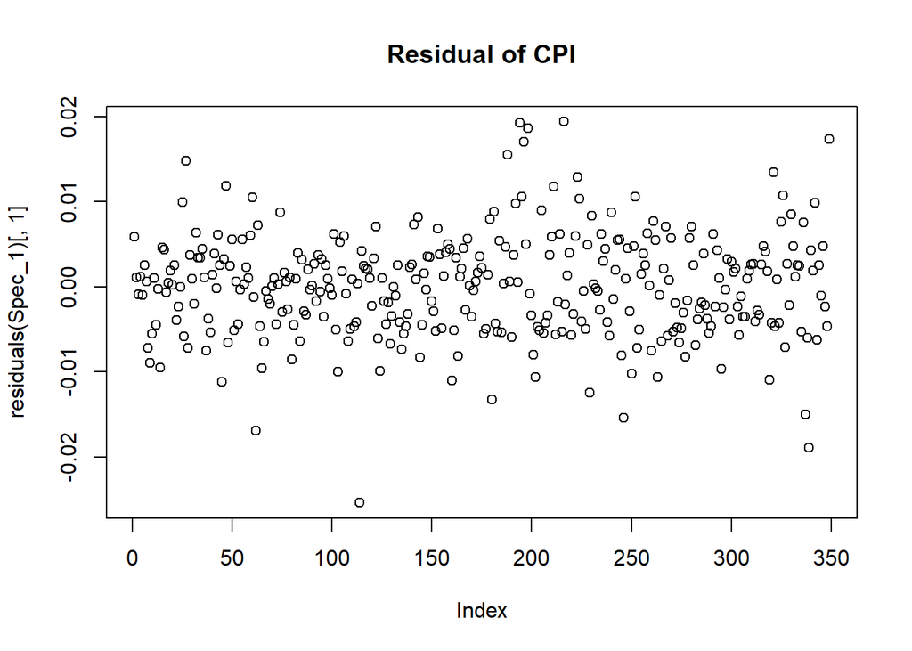

```r
#We first check the residuals of each variable
plot(residuals(Spec_1)[,1],main="Residual of CPI")
```

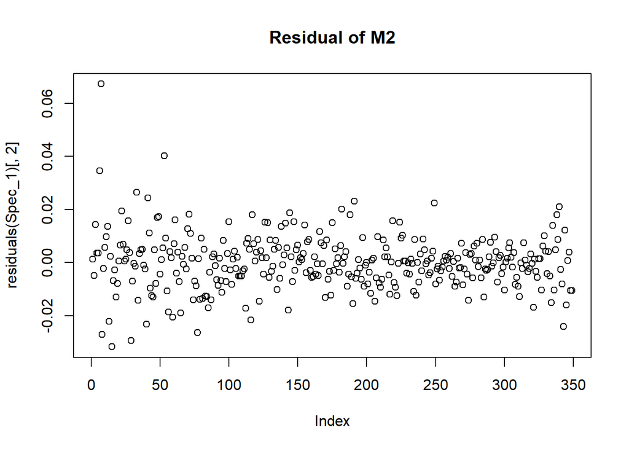

```r
plot(residuals(Spec_1)[,2],main="Residual of M2")
```

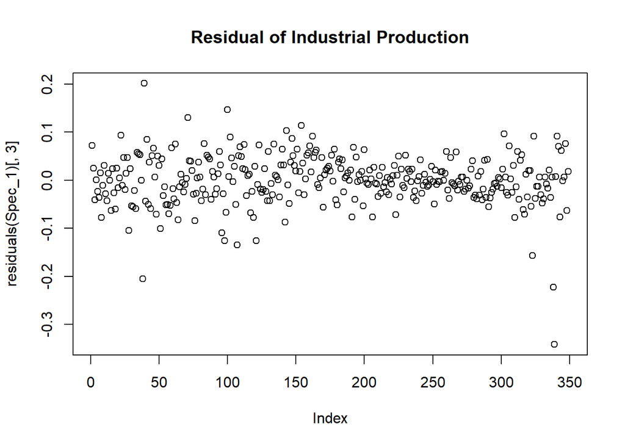

```r
plot(residuals(Spec_1)[,3],main="Residual of Industrial Production")
```

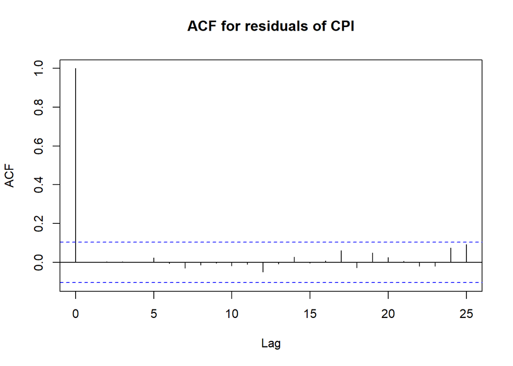

```r
#we move forward to check ACF of the residuals of variables
acf(residuals(Spec_1)[,1],main = "ACF for residuals of CPI")
```

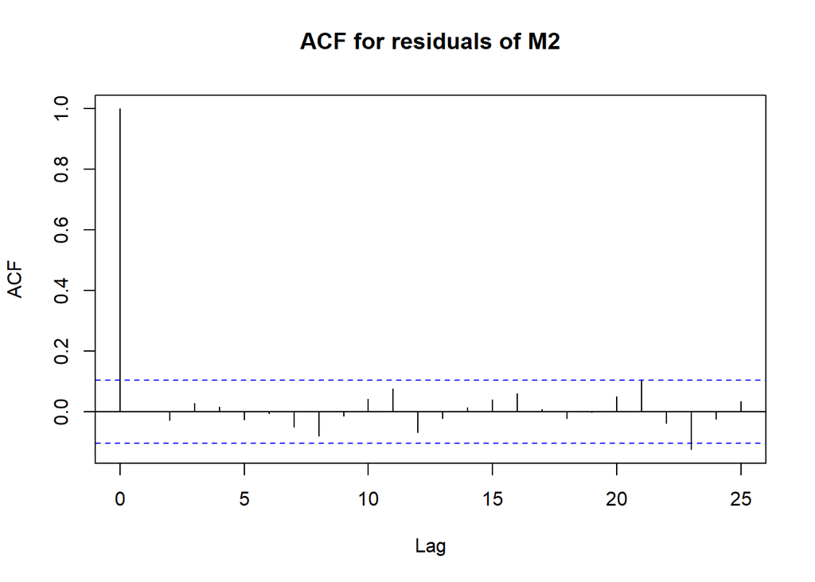

```r
acf(residuals(Spec_1)[,2],main = "ACF for residuals of M2")
```

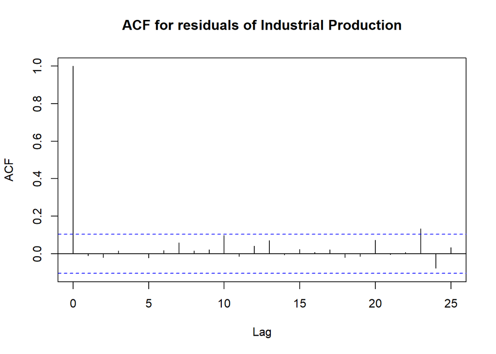

```r
acf(residuals(Spec_1)[,3],main = "ACF for residuals of Industrial Production")
```

```r
#It looks good for a residual ACF.
#(The big spike at the beginning is the unimportant lag 0 correlation.)
```

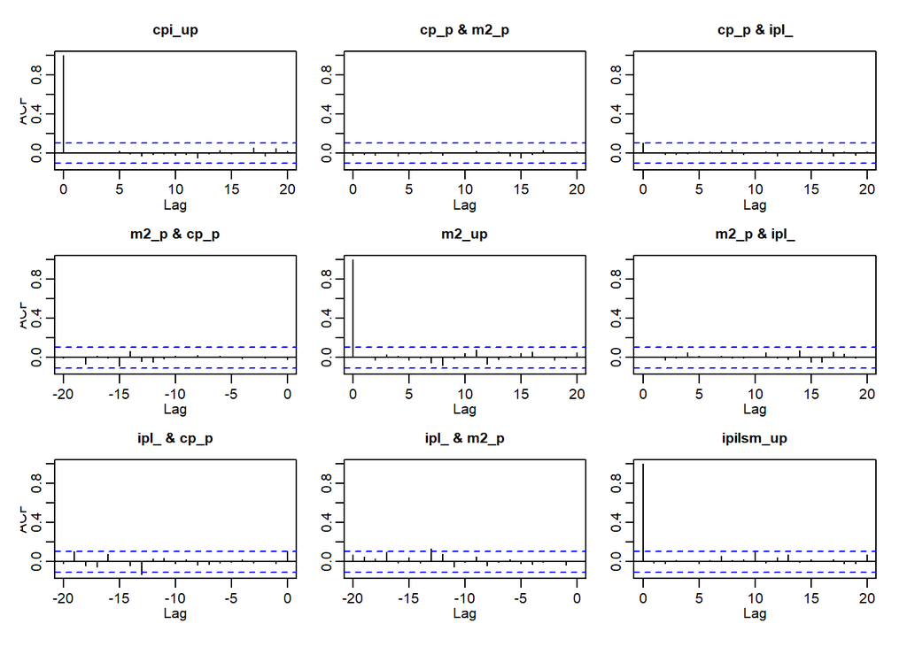

```r
#We may also examine these plots in the cross-correlation matrix provided
acf(residuals(Spec_1))
```

The plots along the diagonal are the individual ACFs for each model’s residuals that we plotted above. In addition, we now see the cross-correlation plots of each set of residuals. Ideally, these would also resemble white noise,which is the case.

```r
#Diagnostic 1 : Serial Correlation
#H_0: No AutoCorrelation is present in residuals
Serial1<- serial.test(x = Spec_1,lags.pt = 12,lags.bg = 12)
Serial1$serial
```

```
##
##  Portmanteau Test (asymptotic)
##
## data:  Residuals of VAR object Spec_1
## Chi-squared = 29.601, df = 0, p-value < 2.2e-16
```

We reject the null hypothesis and conclude that there is presence of serial auto correlation in this specification. Since Auto correlation is not a desirable trait so we may want to switch from VAR(12) to other models.

```r
#Diagnoistic 2 : Hetrosckedacity : ARCH (autoregressive conditionally heteroscedastic) test
#To test for volatality
#H_0 : There are no ARCH effects
Arch1<-arch.test(x = Spec_1,multivariate.only = TRUE,lags.multi = 12)
Arch1
```

```
##
##  ARCH (multivariate)
##
## data:  Residuals of VAR object Spec_1
## Chi-squared = 582.82, df = 432, p-value = 1.626e-06
```

Because the p-value is < 0.05, we reject the null hypothesis and conclude the presence of ARCH(12) effects.

```r
#Diagnostic 3: Normal Distribution of the residuals
#H_0: Errors are normally distributed
Norm1<- normality.test(Spec_1,multivariate.only = TRUE)
Norm1
```

```
## $JB
##
##  JB-Test (multivariate)
##
## data:  Residuals of VAR object Spec_1
## Chi-squared = 1070.9, df = 6, p-value < 2.2e-16
##
##
## $Skewness
##
##  Skewness only (multivariate)
##
## data:  Residuals of VAR object Spec_1
## Chi-squared = 93.725, df = 3, p-value < 2.2e-16
##
##
## $Kurtosis
##
##  Kurtosis only (multivariate)
##
## data:  Residuals of VAR object Spec_1
## Chi-squared = 977.22, df = 3, p-value < 2.2e-16
```

We reject
$$H_0$$
by JB-test and conclude that residual errors are not normally distributed.

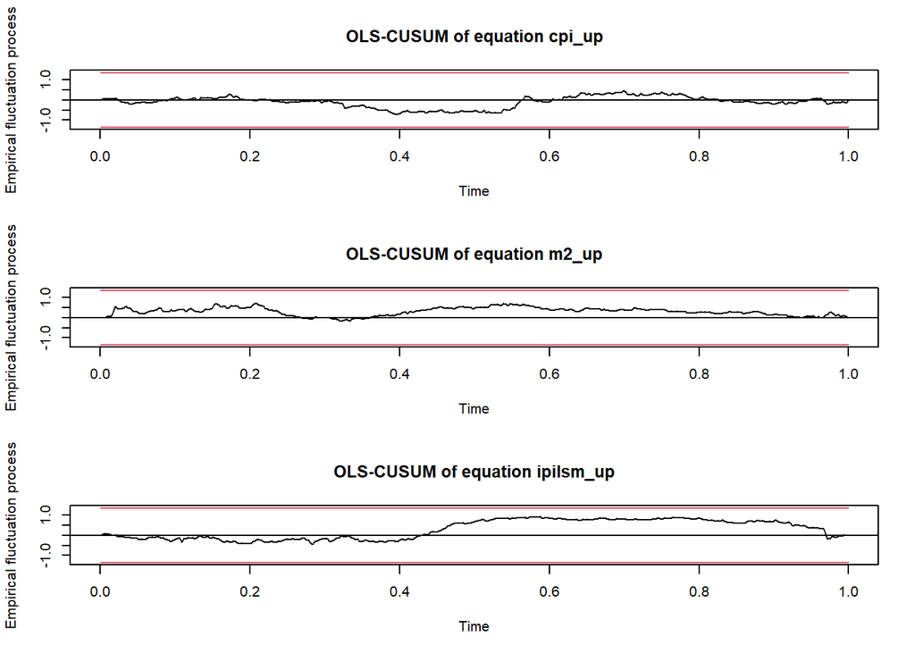

```r
#Diagnonistic4: Testing for Structural Breaks in residuals(Model Stability)
Stab1<- stability(Spec_1,type = "OLS-CUSUM")
plot(Stab1)
```

There are no points along the graph that voilates Upper and Lower Confidence Interval thus Model is Stable.

##Granger Causality

```r
Grangercpi <- causality(Spec_1,cause="cpi_up")
Grangercpi
```

```
## $Granger
##
##  Granger causality H0: cpi_up do not Granger-cause m2_up ipilsm_up
##
## data:  VAR object Spec_1
## F-Test = 1.1529, df1 = 24, df2 = 903, p-value = 0.2779
##
##
## $Instant
##
##  H0: No instantaneous causality between: cpi_up and m2_up ipilsm_up
##
## data:  VAR object Spec_1
## Chi-squared = 3.9338, df = 2, p-value = 0.1399
```

Do not Reject
$$H_0$$
and conclude CPI does not granger causes M2 and Industrial Production

```r
Grangerm2 <- causality(Spec_1,cause="m2_up")
Grangerm2
```

```
## $Granger
##
##  Granger causality H0: m2_up do not Granger-cause cpi_up ipilsm_up
##
## data:  VAR object Spec_1
## F-Test = 1.2021, df1 = 24, df2 = 903, p-value = 0.2299
##
##
## $Instant
##
##  H0: No instantaneous causality between: m2_up and cpi_up ipilsm_up
##
## data:  VAR object Spec_1
## Chi-squared = 0.18255, df = 2, p-value = 0.9128
```

Do not Reject
$$H_0$$
and conclude Money does not granger causes CPI and Industrial Production

```r
Grangeripilsm <- causality(Spec_1,cause="ipilsm_up")
Grangeripilsm
```

```
## $Granger
##
##  Granger causality H0: ipilsm_up do not Granger-cause cpi_up m2_up
##
## data:  VAR object Spec_1
## F-Test = 1.1875, df1 = 24, df2 = 903, p-value = 0.2436
##
##
## $Instant
##
##  H0: No instantaneous causality between: ipilsm_up and cpi_up m2_up
##
## data:  VAR object Spec_1
## Chi-squared = 3.8336, df = 2, p-value = 0.1471
```

Do not reject
$$H_0$$
and conclude Industrial Production does not granger causes CPI and money Supply

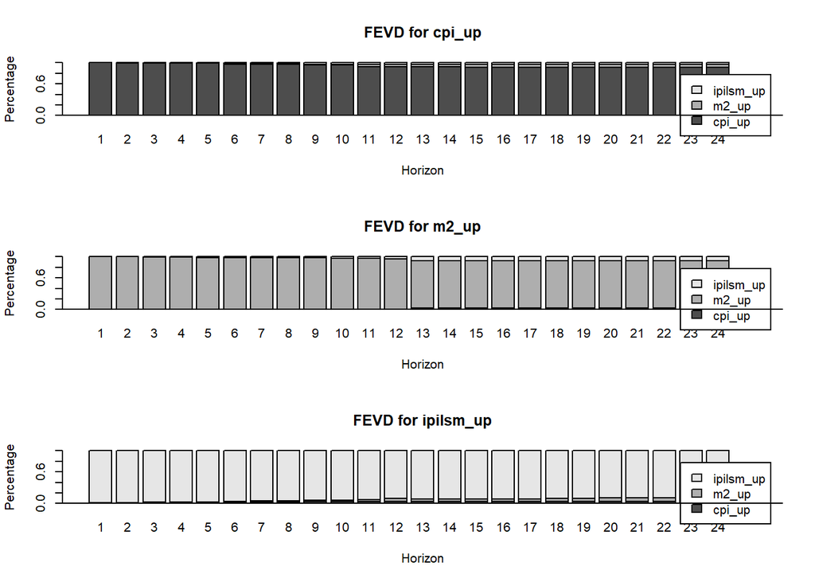

```r
#Variance Decomposition
FEVD1 <- fevd(Spec_1, n.ahead = 24)
plot(FEVD1)
```

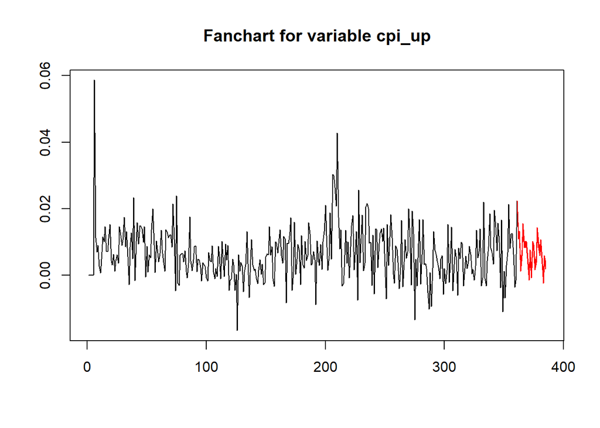

```r
#Forecasting
forecast<- predict(Spec_1,n.ahead = 24,ci = 0.95)
#Build the fan chart
fanchart(forecast,names = "cpi_up",colors = "red")
```

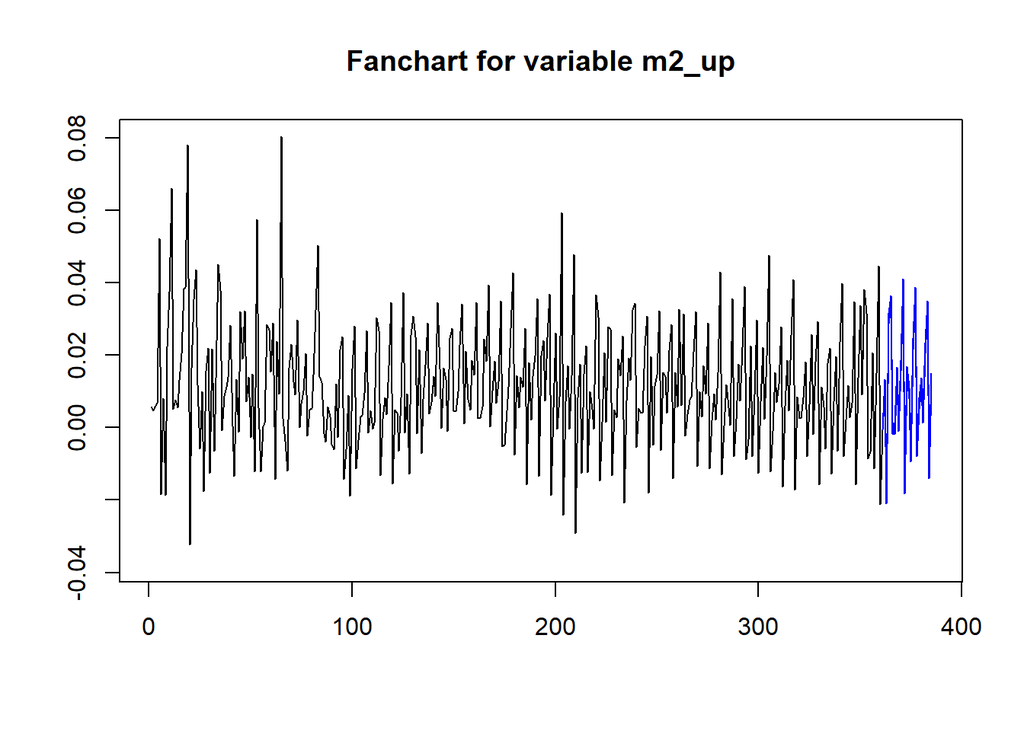

```r
fanchart(forecast,names = "m2_up",colors = "blue")
```

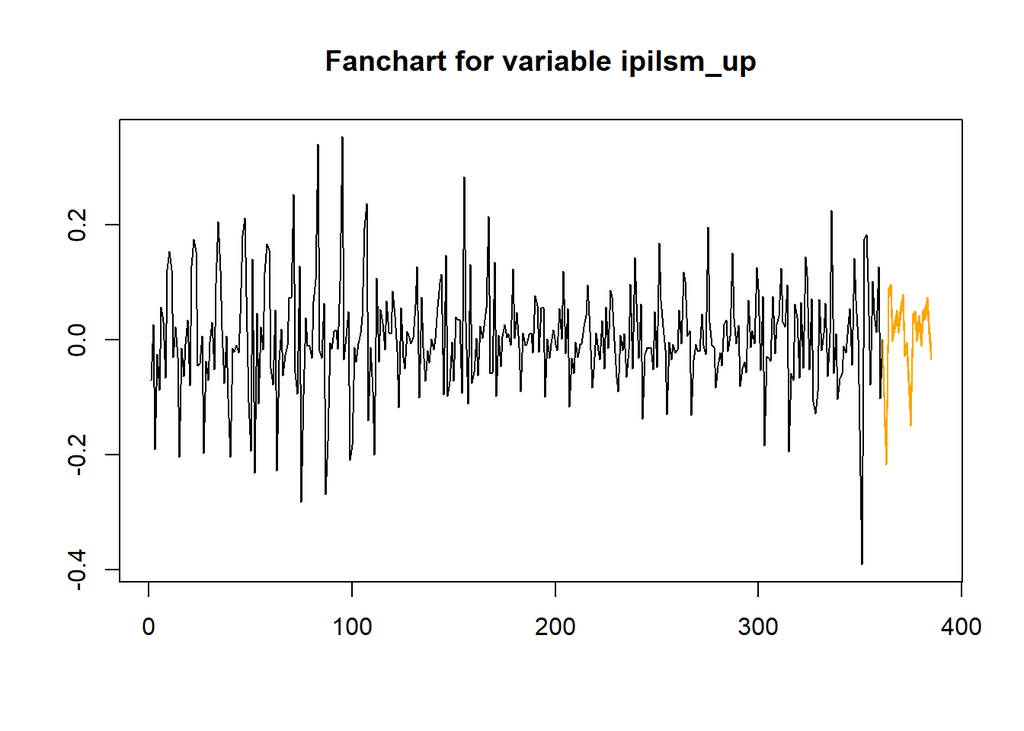

```r
fanchart(forecast,names = "ipilsm_up",colors = "orange")
```